# Data Prepation, Visualisation and Statistics

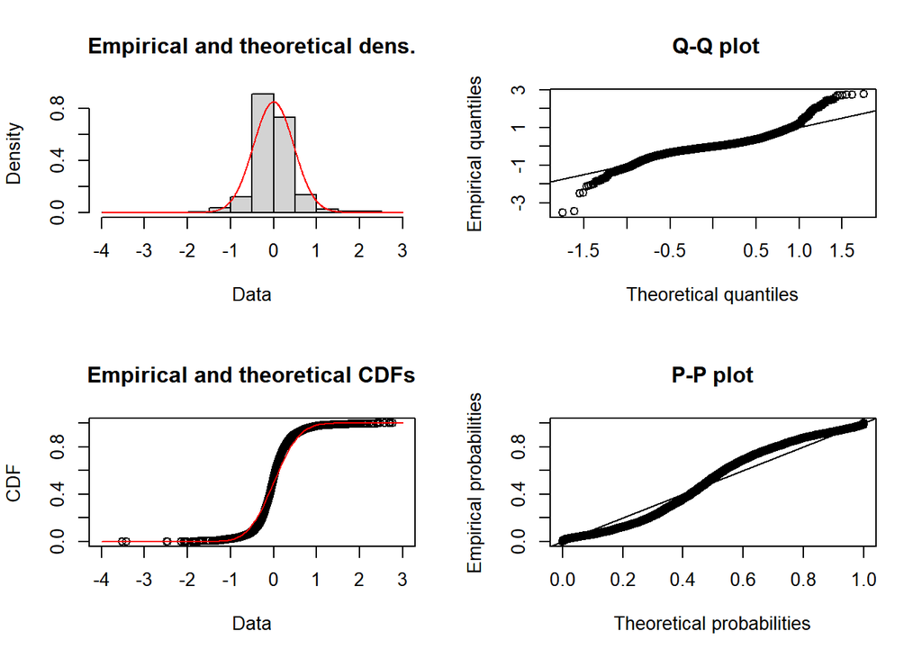

```r
fit.normlog <- fitdist(residuals(Permit_model_log), "norm")
plot(fit.normlog)
```

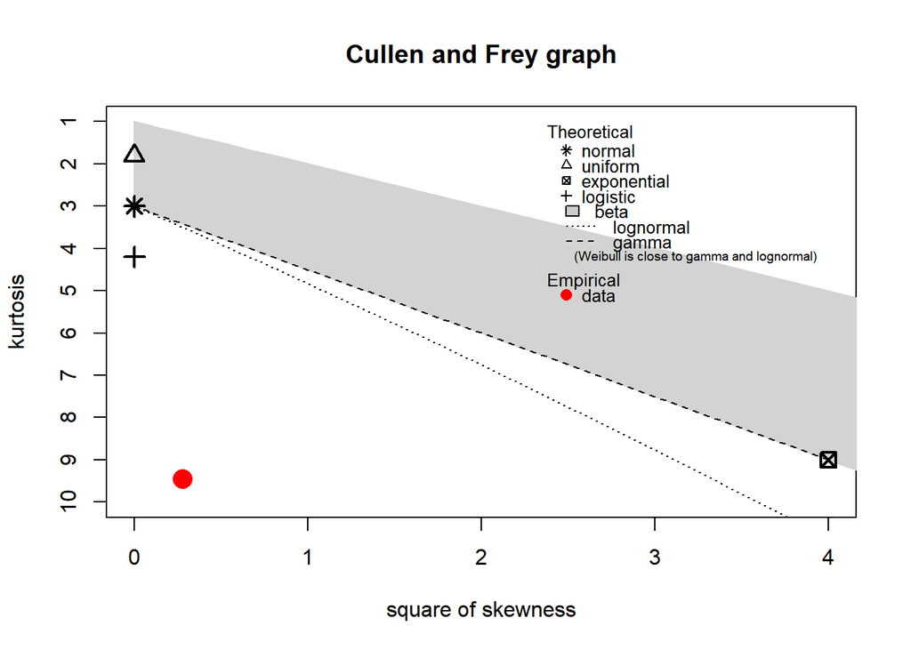

```
## summary statistics
## ------
## min:  -1.526216   max:  1.199274
## median:  -0.009923896
## mean:  3.114352e-15
## estimated sd:  0.2038412
## estimated skewness:  0.5286488
## estimated kurtosis:  9.457648
```

```r
Permit_model_log10<- lmer(log10(Total+1) ~ Area + Date + (1|Citizenship), data = Permit_totals)
descdist(residuals(Permit_model_log10),discrete = FALSE)
```

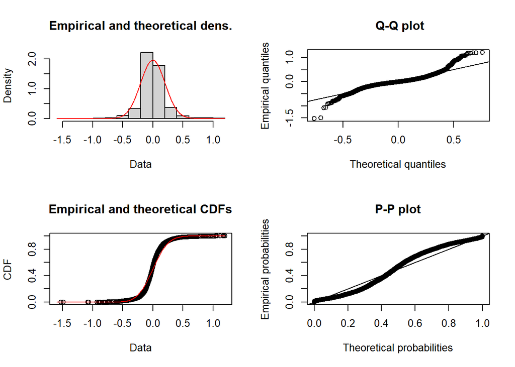

```r
fit.normlog10 <- fitdist(residuals(Permit_model_log10), "norm")
plot(fit.normlog10)
```

```r
fit.normlog$aic
```

```
## [1] 7031.403
```

```r
fit.normlog10$aic
```

```
## [1] -1816.013
```

While this doesn’t result in a normal distribution I was unable to identify distribution family that fit the data better. In an ideal situation the glm (generalised linear model) or gam (general additive model) packages would be used with a most appropriate distribution family, but in this situation I used the log10 transformation as seemed this improved the distribution of the residuals with out overfitting.

```r
emmeans(Permit_model_log10, pairwise~Area,regrid="response",pbkrtest.limit = 5304,lmerTest.limit = 5304)
```

```
## $emmeans
##  Area         response  SE  df lower.CL upper.CL
##  Non-Schengen     3297 654 204     2007     4586
##  Schengen         3696 753 227     2212     5181
##
## Degrees-of-freedom method: inherited from kenward-roger when re-gridding
## Confidence level used: 0.95
##
## $contrasts
##  contrast                  estimate  SE  df t.ratio p.value
##  (Non-Schengen) - Schengen     -400 211 204  -1.897  0.0593
##
## Degrees-of-freedom method: inherited from kenward-roger when re-gridding
```

These results indicate that, while borderline there is no significant different in Successful permit application between Schengen and Non-schengen applicants.